# Lab 5 Deep and Wide Network Architectures

1. Ayesh Madushanka Mahamada Kalapuwage

```python
import pandas as pd
import missingno as mn
import numpy as np
import seaborn as sns
from matplotlib import pyplot as plt
from sklearn.model_selection import train_test_split
from scipy.special import expit
import sys
from sklearn.metrics import accuracy_score
import warnings
import copy
warnings.simplefilter(action='ignore', category=UserWarning)
plt.style.use('ggplot')
from sklearn.metrics import roc_curve
from sklearn.metrics import roc_auc_score
```

```python
df=pd.read_csv('Health_data.csv')
df.head()
```

|  | case_id | Hospital_code | Hospital_type_code | City_Code_Hospital | Hospital_region_code | Available Extra Rooms in Hospital | Department | Ward_Type | Ward_Facility_Code | Bed Grade | patientid | City_Code_Patient | Type of Admission | Severity of Illness | Visitors with Patient | Age | Admission_Deposit | Stay |
| --- | --- | --- | --- | --- | --- | --- | --- | --- | --- | --- | --- | --- | --- | --- | --- | --- | --- | --- |
| 0 | 1 | 8 | c | 3 | Z | 3 | radiotherapy | R | F | 2.0 | 31397 | 7.0 | Emergency | Extreme | 2 | 51-60 | 4911.0 | 0-10 |
| 1 | 2 | 2 | c | 5 | Z | 2 | radiotherapy | S | F | 2.0 | 31397 | 7.0 | Trauma | Extreme | 2 | 51-60 | 5954.0 | 41-50 |
| 2 | 3 | 10 | e | 1 | X | 2 | anesthesia | S | E | 2.0 | 31397 | 7.0 | Trauma | Extreme | 2 | 51-60 | 4745.0 | 31-40 |
| 3 | 4 | 26 | b | 2 | Y | 2 | radiotherapy | R | D | 2.0 | 31397 | 7.0 | Trauma | Extreme | 2 | 51-60 | 7272.0 | 41-50 |
| 4 | 5 | 26 | b | 2 | Y | 2 | radiotherapy | S | D | 2.0 | 31397 | 7.0 | Trauma | Extreme | 2 | 51-60 | 5558.0 | 41-50 |

Business case:

Recent covid 19 pandemic has raised the heathcare facilities throughtout the world. Length Of Stay(LOS) is the major concern of the heathcare management now. Why?

Because this LOS parameter helps to identify the high LOS patients at the time of admition. Once identified, patients with high LOS risk can have their treatment plan to minimize the LOS and reducing the chance of staff/visitors infection. Furthermore the knowledge gain by LOS can use to rooms and beds allocation planning.

High risk LOS is called more than a month and low LOS called lower than a month.

Unrelated columns should be dropped.

1. case_id is just a countdown of patients
2. Hospital_code is not related to the LOS
3. City_code is not related
4. patientid is not related
5. Admission deposite also not important.

```python
df.drop(['case_id','Hospital_code','City_Code_Hospital','patientid','Admission_Deposit','City_Code_Patient'],axis=1, inplace=True)
```

```python
df
```

|  | Hospital_type_code | Hospital_region_code | Available Extra Rooms in Hospital | Department | Ward_Type | Ward_Facility_Code | Bed Grade | Type of Admission | Severity of Illness | Visitors with Patient | Age | Stay |
| --- | --- | --- | --- | --- | --- | --- | --- | --- | --- | --- | --- | --- |
| 0 | c | Z | 3 | radiotherapy | R | F | 2.0 | Emergency | Extreme | 2 | 51-60 | 0-10 |
| 1 | c | Z | 2 | radiotherapy | S | F | 2.0 | Trauma | Extreme | 2 | 51-60 | 41-50 |
| 2 | e | X | 2 | anesthesia | S | E | 2.0 | Trauma | Extreme | 2 | 51-60 | 31-40 |
| 3 | b | Y | 2 | radiotherapy | R | D | 2.0 | Trauma | Extreme | 2 | 51-60 | 41-50 |
| 4 | b | Y | 2 | radiotherapy | S | D | 2.0 | Trauma | Extreme | 2 | 51-60 | 41-50 |
| ... | ... | ... | ... | ... | ... | ... | ... | ... | ... | ... | ... | ... |
| 318433 | a | X | 3 | radiotherapy | Q | F | 4.0 | Emergency | Moderate | 3 | 41-50 | 11-20 |
| 318434 | a | X | 2 | anesthesia | Q | E | 4.0 | Urgent | Moderate | 4 | 81-90 | 31-40 |
| 318435 | a | X | 3 | gynecology | R | F | 4.0 | Emergency | Minor | 3 | 71-80 | 11-20 |
| 318436 | b | Y | 3 | anesthesia | Q | D | 3.0 | Trauma | Minor | 5 | 11-20 | 11-20 |
| 318437 | a | Y | 5 | gynecology | Q | C | 2.0 | Emergency | Minor | 2 | 11-20 | 0-10 |

318438 rows × 12 columns

```python
df.Stay.value_counts()
```

```
21-30                 87491
11-20                 78139
31-40                 55159
51-60                 35018
0-10                  23604
41-50                 11743
71-80                 10254
More than 100 Days     6683
81-90                  4838
91-100                 2765
61-70                  2744
Name: Stay, dtype: int64
```

```python
df.Stay.replace(to_replace=['0-10','11-20','21-30','31-40','41-50','51-60','61-70','71-80','81-90','91-100','More than 100 Days'],
                           value=['<month','<month','<month','>month','>month','>month','>month','>month','>month','>month','>month',],
                           inplace=True)
print(df.Stay.value_counts())
```

```
<month    189234
>month    129204
Name: Stay, dtype: int64
```

```python
df.isnull().sum()
```

```
Hospital_type_code                     0
Hospital_region_code                   0
Available Extra Rooms in Hospital      0
Department                             0
Ward_Type                              0
Ward_Facility_Code                     0
Bed Grade                            113
Type of Admission                      0
Severity of Illness                    0
Visitors with Patient                  0
Age                                    0
Stay                                   0
dtype: int64
```

```python
df=df.dropna(axis=0,how='any')
df.isnull().sum()
```

```
Hospital_type_code                   0
Hospital_region_code                 0
Available Extra Rooms in Hospital    0
Department                           0
Ward_Type                            0
Ward_Facility_Code                   0
Bed Grade                            0
Type of Admission                    0
Severity of Illness                  0
Visitors with Patient                0
Age                                  0
Stay                                 0
dtype: int64
```

```python
df.dtypes
```

```
Hospital_type_code                    object
Hospital_region_code                  object
Available Extra Rooms in Hospital      int64
Department                            object
Ward_Type                             object
Ward_Facility_Code                    object
Bed Grade                            float64
Type of Admission                     object
Severity of Illness                   object
Visitors with Patient                  int64
Age                                   object
Stay                                  object
dtype: object
```

#### Q2-Identify groups of features in your data that should be combined into cross-product features. Provide justification for why these features should be crossed (or why some features should not be crossed)

```python
print(df.columns)
```

```
Index(['Hospital_type_code', 'Hospital_region_code',
       'Available Extra Rooms in Hospital', 'Department', 'Ward_Type',
       'Ward_Facility_Code', 'Bed Grade', 'Type of Admission',
       'Severity of Illness', 'Visitors with Patient', 'Age', 'Stay'],
      dtype='object')
```

```python
categorical_headers = ['Hospital_type_code', 'Hospital_region_code','Department', 'Ward_Type',
       'Ward_Facility_Code','Severity of Illness','Age']
```

```python
for col in categorical_headers:
    vals = df[col].unique()
    print(col,'has',len(vals),'unique values:')
    print(vals)
```

```
Hospital_type_code has 7 unique values:
['c' 'e' 'b' 'a' 'f' 'd' 'g']
Hospital_region_code has 3 unique values:
['Z' 'X' 'Y']
Department has 5 unique values:
['radiotherapy' 'anesthesia' 'gynecology' 'TB & Chest disease' 'surgery']
Ward_Type has 6 unique values:
['R' 'S' 'Q' 'P' 'T' 'U']
Ward_Facility_Code has 6 unique values:
['F' 'E' 'D' 'B' 'A' 'C']
Severity of Illness has 3 unique values:
['Extreme' 'Moderate' 'Minor']
Age has 10 unique values:
['51-60' '71-80' '31-40' '41-50' '81-90' '61-70' '21-30' '11-20' '0-10'
 '91-100']
```

```python
cross_columns = [#['Hospital_type_code', 'Hospital_region_code'],
                 #['Ward_Type','Ward_Facility_Code'],
                 ['Department','Severity of Illness','Age']
                 ]
```

These three combinations corelated.

1. Hospital_type_code + Hospital_region_code is talking about the quality and physical location of the hospitals which determines the LOS(number of staying days) of the patients.
1. Ward_Type + Ward_Facility_Code also determines the quality of the wards.
1. Department + Severity of Illness + Age is the most crucial one because these three features directly effect the LOC determination process and I will select this one as cross column.

e.g.- If an old patient suffering from cancer in extreme condition, needs to admit into radiotherapy department and takes much more time than the one who admits into gynocology department. These three are the main factors that determine the LOC.

#### Q3 - Choose and explain what metric(s) you will use to evaluate your algorithm’s performance. You should give a detailed argument for why this (these) metric(s) are appropriate on your data.

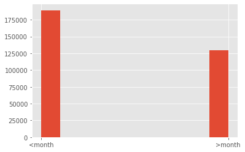

```python
plt.hist(df.Stay)
```

Initially dataset was multiclass classification problem but most of the classes had very law number of values. So I decided to convert it into binary classification and check whether patients stay in the hospital less than a month or grater than month.

Now my both classes can be considered as approximately balanced. Grater than one month is taken as 1 and less than is 0. Which is the worst case False Positive or False Negative?

If a patient is low risk LOS and predicts as high risk(False positive), the staff will take action to reduce the LOC and that will get the patient disappointed and waste of the healthcare resourses. On the other hand, False Negative case, there would be a risk to staff get infected.

False Negative is the worst and also we should consider about False positive case too. Recall is important and precision also takes into account. I choose F1 score as my best classification metrix.

#### Q4 -Choose the method you will use for dividing your data into training and testing (i.e., are you using Stratified 10-fold cross validation? Shuffle splits? Why?). Explain why your chosen method is appropriate or use more than one method as appropriate. Argue why your cross validation method is a realistic mirroring of how an algorithm would be used in practice.

```python
y=df.Stay.to_numpy()
X=df.iloc[:, df.columns != 'Stay'].to_numpy()
```

```python
from sklearn.model_selection import train_test_split

X_train, X_test, y_train, y_test = train_test_split(random_state=111,shuffle=True,
    X,y,test_size = 0.2)
print(X_train.shape)
print(y_train.shape)
print(X_test.shape)
print(y_test.shape)
```

```
(254660, 11)
(254660,)
(63665, 11)
(63665,)
```

1. I do not need to use Stratified 10 fold cross validation method because my classes are approximately balanced.
2. I choosed shuffle Splitting because to avoid the elements of bias and patterns in the spllits dataset before training the model.

During the each round Kfold uses one fold as test and the remaining 9 as training. However, in shufflesplit, during each round n it will only use training and testing set from iteration n. When the datset bigger and bigger, cross validation time also increases, making the shuffle split a more attactive method.

# Modelling

#### Q6-Create at least three combined wide and deep networks to classify your data using Keras. Visualize the performance of the network on the training data and validation data in the same plot versus the training iterations. Note: use the "history" return parameter that is part of Keras "fit" function to easily access this data.

```python
from tensorflow.keras.layers import Dense, Activation, Input
from tensorflow.keras.models import Model
#keras.__version__
```

```python
df_train=pd.DataFrame(X_train)
df_train['y_train']=y_train
df_train=df_train.rename({0:'Hospital_type_code', 1:'Hospital_region_code',
       2:'Extra_Rooms', 3:'Department', 4:'Ward_Type',
       5:'Ward_Facility_Code', 6:'Bed_Grade', 7:'Admission_type',
       8:'Severity', 9:'Visitors', 10:'Age', 'y_train':'Stay'},axis=1)
```

```python
df_test=pd.DataFrame(X_test)
df_test['y_test']=y_test
df_test=df_test.rename({0:'Hospital_type_code', 1:'Hospital_region_code',
       2:'Extra_Rooms', 3:'Department', 4:'Ward_Type',
       5:'Ward_Facility_Code', 6:'Bed_Grade', 7:'Admission_type',
       8:'Severity', 9:'Visitors', 10:'Age', 'y_test':'Stay'},axis=1)
```

```python
df_test.head()
```

[output not shown]

```python
from sklearn.preprocessing import LabelEncoder
from sklearn.preprocessing import StandardScaler

categorical_headers = ['Hospital_type_code','Hospital_region_code',
       'Department','Ward_Type',
       'Ward_Facility_Code','Bed_Grade', 'Admission_type',
       'Severity', 'Age']


# define objects that can encode each variable as integer
encoders = dict() # save each encoder in dictionary

# train all encoders (special case the target 'income')
for col in categorical_headers+['Stay']:
    if col=="Stay":
        # special case the target, just replace the column
        tmp = LabelEncoder()
        df_train[col] = tmp.fit_transform(df_train[col])
        df_test[col] = tmp.transform(df_test[col])
    else:
        # integer encode strings that are features
        encoders[col] = LabelEncoder() # save the encoder
        df_train[col+'_int'] = encoders[col].fit_transform(df_train[col])
        df_test[col+'_int'] = encoders[col].transform(df_test[col])
        # ========================================================
# scale the numeric, continuous variables
numeric_headers = ['Extra_Rooms', 'Visitors']

for col in numeric_headers:
    df_train[col] = df_train[col].astype(np.float)
    df_test[col] = df_test[col].astype(np.float)

    ss = StandardScaler()
    df_train[col] = ss.fit_transform(df_train[col].values.reshape(-1, 1))
    df_test[col] = ss.transform(df_test[col].values.reshape(-1, 1))

df_test.head()
```

|  | Hospital_type_code | Hospital_region_code | Extra_Rooms | Department | Ward_Type | Ward_Facility_Code | Bed_Grade | Admission_type | Severity | Visitors | ... | Stay | Hospital_type_code_int | Hospital_region_code_int | Department_int | Ward_Type_int | Ward_Facility_Code_int | Bed_Grade_int | Admission_type_int | Severity_int | Age_int |
| --- | --- | --- | --- | --- | --- | --- | --- | --- | --- | --- | --- | --- | --- | --- | --- | --- | --- | --- | --- | --- | --- |
| 0 | a | Z | 0.691425 | radiotherapy | R | F | 3.0 | Emergency | Extreme | -0.727408 | ... | 0 | 0 | 2 | 3 | 2 | 5 | 2 | 0 | 0 | 4 |
| 1 | b | X | -1.026186 | gynecology | R | F | 3.0 | Trauma | Minor | 0.405274 | ... | 1 | 1 | 0 | 2 | 2 | 5 | 2 | 1 | 1 | 4 |
| 2 | a | Y | -1.026186 | gynecology | R | C | 3.0 | Trauma | Moderate | -0.161067 | ... | 0 | 0 | 1 | 2 | 2 | 2 | 2 | 1 | 2 | 4 |
| 3 | b | X | -1.026186 | gynecology | R | F | 4.0 | Urgent | Moderate | -0.727408 | ... | 0 | 1 | 0 | 2 | 2 | 5 | 3 | 2 | 2 | 7 |
| 4 | b | Y | 1.550231 | gynecology | Q | D | 3.0 | Emergency | Extreme | 0.405274 | ... | 1 | 1 | 1 | 2 | 1 | 3 | 2 | 0 | 0 | 4 |

5 rows × 21 columns

```python
# let's start as simply as possible, without any feature preprocessing
categorical_headers_ints = [x+'_int' for x in categorical_headers]

# we will forego one-hot encoding right now and instead just use all inputs as-is
#   this is just to get an example running in Keras (its not a good idea)
feature_columns = categorical_headers_ints+numeric_headers

import pprint
pp = pprint.PrettyPrinter(indent=4)

print(f"We will use the following {len(feature_columns)} features:")
pp.pprint(feature_columns)

# combine the features into a single large matrix
X_train = df_train[feature_columns].to_numpy()
X_test = df_test[feature_columns].to_numpy()

y_train = df_train['Stay'].values.astype(np.int)
y_test = df_test['Stay'].values.astype(np.int)
```

```
We will use the following 11 features:
[   'Hospital_type_code_int',
    'Hospital_region_code_int',
    'Department_int',
    'Ward_Type_int',
    'Ward_Facility_Code_int',
    'Bed_Grade_int',
    'Admission_type_int',
    'Severity_int',
    'Age_int',
    'Extra_Rooms',
    'Visitors']
```

```python
# Now let's define the architecture for a multi-layer network

# First, lets setup the input size
num_features = X_train.shape[1]
input_tensor = Input(shape=(num_features,))

# a layer instance is callable on a tensor, and returns a tensor
# Dense means a fully connected layer, with 10 hidden neurons and a bias term
x = Dense(units=10, activation='relu')(input_tensor)
x = Dense(units=5, activation='tanh')(x)
predictions = Dense(1, activation='sigmoid')(x)

# This creates a model that includes
# the Input layer and three Dense layers
model = Model(inputs=input_tensor, outputs=predictions)
```

```python
model.compile(optimizer='sgd',
              loss='mean_squared_error',
              metrics=['accuracy'])

model.summary()
```

```
Model: "model_19"
_________________________________________________________________
Layer (type)                 Output Shape              Param #
=================================================================
input_16 (InputLayer)        [(None, 11)]              0
_________________________________________________________________
dense_45 (Dense)             (None, 10)                120
_________________________________________________________________
dense_46 (Dense)             (None, 5)                 55
_________________________________________________________________
dense_47 (Dense)             (None, 1)                 6
=================================================================
Total params: 181
Trainable params: 181
Non-trainable params: 0
_________________________________________________________________
```

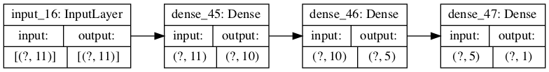

```python
from tensorflow.keras.utils import plot_model

# you will need to install pydot properly on your machine to get this running
plot_model(
    model, to_file='model.png', show_shapes=True, show_layer_names=True,
    rankdir='LR', expand_nested=False, dpi=96
)
```

```python
%%time

model.fit(X_train, y_train, epochs=10, batch_size=50, verbose=1)

# now lets see how well the model performed
from sklearn import metrics as mt
yhat_proba = model.predict(X_test) # sigmoid output probabilities
yhat = np.round(yhat_proba) # round to get binary class

print(mt.confusion_matrix(y_test,yhat))
print(mt.classification_report(y_test,yhat))
```

```
Train on 254660 samples
[[35860  2015]
 [11273 14517]]
              precision    recall  f1-score   support

           0       0.76      0.95      0.84     37875
           1       0.88      0.56      0.69     25790

    accuracy                           0.79     63665
   macro avg       0.82      0.75      0.76     63665
weighted avg       0.81      0.79      0.78     63665

CPU times: user 1min 12s, sys: 8.03 s, total: 1min 20s
Wall time: 41.3 s
```

```python
from tensorflow.keras.layers import Embedding
from tensorflow.keras.layers import concatenate
import tensorflow as tf

# start by getting only the categorical variables
# these matrices are all integers
X_train = df_train[categorical_headers_ints].to_numpy()
X_test = df_test[categorical_headers_ints].to_numpy()

embed_branches = []
all_branch_outputs = [] # this is where we will keep track of output of each branch

# feed in the entire matrix of categircal variables
input_branch = Input(shape=(X_train.shape[1],),
                     dtype='int64',
                     name='categorical')

# for each categorical variable
for idx,col in enumerate(categorical_headers_ints):

    # what the maximum integer value for this variable?
    # which is the same as the number of categories
    N = max(df_train[col].max(),df_test[col].max())+1

    # this line of code does this: input_branch[:,idx]
    x = tf.gather(input_branch, idx, axis=1)

    # now use an embedding to deal with integers as if they were one hot encoded
    x = Embedding(input_dim=N,
                  output_dim=int(np.sqrt(N)),
                  input_length=1, name=col+'_embed')(x)

    # save these outputs in list to concatenate later
    all_branch_outputs.append(x)
    # now concatenate the outputs and add a fully connected layer
final_branch = concatenate(all_branch_outputs, name='concat_1')
final_branch = Dense(units=1,
                     activation='sigmoid',
                     name='combined')(final_branch)

model = Model(inputs=input_branch, outputs=final_branch)

model.compile(optimizer='sgd',
              loss='mean_squared_error',
              metrics=['accuracy'])

model.summary()
```

```
Model: "model_20"
__________________________________________________________________________________________________
Layer (type)                    Output Shape         Param #     Connected to
==================================================================================================
categorical (InputLayer)        [(None, 9)]          0
__________________________________________________________________________________________________
tf_op_layer_GatherV2_27 (Tensor [(None,)]            0           categorical[0][0]
__________________________________________________________________________________________________
tf_op_layer_GatherV2_28 (Tensor [(None,)]            0           categorical[0][0]
__________________________________________________________________________________________________
tf_op_layer_GatherV2_29 (Tensor [(None,)]            0           categorical[0][0]
__________________________________________________________________________________________________
tf_op_layer_GatherV2_30 (Tensor [(None,)]            0           categorical[0][0]
__________________________________________________________________________________________________
tf_op_layer_GatherV2_31 (Tensor [(None,)]            0           categorical[0][0]
__________________________________________________________________________________________________
tf_op_layer_GatherV2_32 (Tensor [(None,)]            0           categorical[0][0]
__________________________________________________________________________________________________
tf_op_layer_GatherV2_33 (Tensor [(None,)]            0           categorical[0][0]
__________________________________________________________________________________________________
tf_op_layer_GatherV2_34 (Tensor [(None,)]            0           categorical[0][0]
__________________________________________________________________________________________________
tf_op_layer_GatherV2_35 (Tensor [(None,)]            0           categorical[0][0]
__________________________________________________________________________________________________
Hospital_type_code_int_embed (E (None, 2)            14          tf_op_layer_GatherV2_27[0][0]
__________________________________________________________________________________________________
Hospital_region_code_int_embed  (None, 1)            3           tf_op_layer_GatherV2_28[0][0]
__________________________________________________________________________________________________
Department_int_embed (Embedding (None, 2)            10          tf_op_layer_GatherV2_29[0][0]
__________________________________________________________________________________________________
Ward_Type_int_embed (Embedding) (None, 2)            12          tf_op_layer_GatherV2_30[0][0]
__________________________________________________________________________________________________
Ward_Facility_Code_int_embed (E (None, 2)            12          tf_op_layer_GatherV2_31[0][0]
__________________________________________________________________________________________________
Bed_Grade_int_embed (Embedding) (None, 2)            8           tf_op_layer_GatherV2_32[0][0]
__________________________________________________________________________________________________
Admission_type_int_embed (Embed (None, 1)            3           tf_op_layer_GatherV2_33[0][0]
__________________________________________________________________________________________________
Severity_int_embed (Embedding)  (None, 1)            3           tf_op_layer_GatherV2_34[0][0]
__________________________________________________________________________________________________
Age_int_embed (Embedding)       (None, 3)            30          tf_op_layer_GatherV2_35[0][0]
__________________________________________________________________________________________________
concat_1 (Concatenate)          (None, 16)           0           Hospital_type_code_int_embed[0][0
                                                                 Hospital_region_code_int_embed[0]
                                                                 Department_int_embed[0][0]
                                                                 Ward_Type_int_embed[0][0]
                                                                 Ward_Facility_Code_int_embed[0][0
                                                                 Bed_Grade_int_embed[0][0]
                                                                 Admission_type_int_embed[0][0]
                                                                 Severity_int_embed[0][0]
                                                                 Age_int_embed[0][0]
__________________________________________________________________________________________________
combined (Dense)                (None, 1)            17          concat_1[0][0]
==================================================================================================
Total params: 112
Trainable params: 112
Non-trainable params: 0
__________________________________________________________________________________________________
```

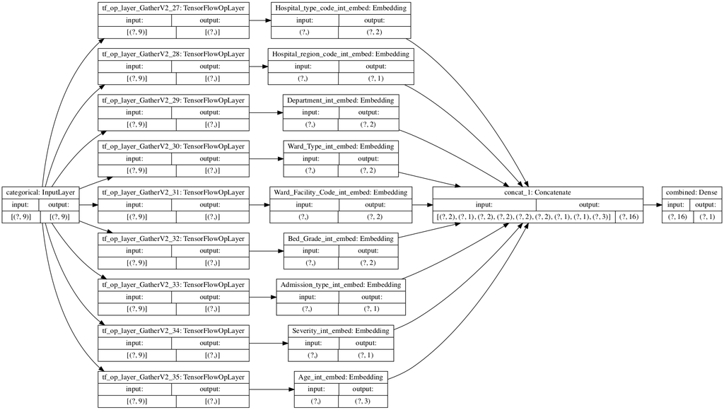

```python
plot_model(
    model, to_file='model.png', show_shapes=True, show_layer_names=True,
    rankdir='LR', expand_nested=False, dpi=96
)
```

```python
%%time

model.fit(X_train, y_train, epochs=10, batch_size=50, verbose=1)

from sklearn import metrics as mt
yhat_proba = model.predict(X_test)
yhat = np.round(yhat_proba)
print(mt.confusion_matrix(y_test,yhat))
print(mt.classification_report(y_test,yhat))
```

```
Train on 254660 samples
[[31540  6335]
 [17275  8515]]
              precision    recall  f1-score   support

           0       0.65      0.83      0.73     37875
           1       0.57      0.33      0.42     25790

    accuracy                           0.63     63665
   macro avg       0.61      0.58      0.57     63665
weighted avg       0.62      0.63      0.60     63665

CPU times: user 2min 34s, sys: 17.2 s, total: 2min 52s
Wall time: 1min 13s
```

```python
# sandbox for looking at different categorical variables
for col in categorical_headers:
    vals = df_train[col].unique()
    print(col,'has', len(vals), 'unique values:')
    print(vals)
```

```
Hospital_type_code has 7 unique values:
['a' 'd' 'c' 'e' 'b' 'f' 'g']
Hospital_region_code has 3 unique values:
['Z' 'X' 'Y']
Department has 5 unique values:
['gynecology' 'anesthesia' 'radiotherapy' 'TB & Chest disease' 'surgery']
Ward_Type has 6 unique values:
['R' 'S' 'Q' 'T' 'P' 'U']
Ward_Facility_Code has 6 unique values:
['F' 'B' 'A' 'E' 'D' 'C']
Bed_Grade has 4 unique values:
[3.0 2.0 4.0 1.0]
Admission_type has 3 unique values:
['Trauma' 'Urgent' 'Emergency']
Severity has 3 unique values:
['Moderate' 'Minor' 'Extreme']
Age has 10 unique values:
['61-70' '51-60' '41-50' '71-80' '11-20' '31-40' '21-30' '91-100' '0-10'
 '81-90']
```

```python
# a quick example of crossing some columns

cols_list = ['Department','Severity','Age']

# 1. create crossed labels by string join operation
X_crossed_train = df_train[cols_list].apply(lambda x: '_'.join(x), axis=1)
X_crossed_test = df_test[cols_list].apply(lambda x: '_'.join(x), axis=1)

# combine together for training
all_vals = np.hstack((X_crossed_train.to_numpy(),  X_crossed_test.to_numpy()))
print(np.unique(all_vals))

# 2. encode as integers, stacking all possibilities
enc = LabelEncoder()
enc.fit(all_vals)

encoded_vals_train = enc.transform(X_crossed_train)
encoded_vals_test  = enc.transform(X_crossed_test)

print(np.min(encoded_vals_train), np.max(encoded_vals_train))
```

```
['TB & Chest disease_Extreme_0-10' 'TB & Chest disease_Extreme_11-20'
 'TB & Chest disease_Extreme_21-30' 'TB & Chest disease_Extreme_31-40'
 'TB & Chest disease_Extreme_41-50' 'TB & Chest disease_Extreme_51-60'
 'TB & Chest disease_Extreme_61-70' 'TB & Chest disease_Extreme_71-80'
 'TB & Chest disease_Extreme_81-90' 'TB & Chest disease_Extreme_91-100'
 'TB & Chest disease_Minor_0-10' 'TB & Chest disease_Minor_11-20'
 'TB & Chest disease_Minor_21-30' 'TB & Chest disease_Minor_31-40'
 'TB & Chest disease_Minor_41-50' 'TB & Chest disease_Minor_51-60'
 'TB & Chest disease_Minor_61-70' 'TB & Chest disease_Minor_71-80'
 'TB & Chest disease_Minor_81-90' 'TB & Chest disease_Minor_91-100'
 'TB & Chest disease_Moderate_0-10' 'TB & Chest disease_Moderate_11-20'
 'TB & Chest disease_Moderate_21-30' 'TB & Chest disease_Moderate_31-40'
 'TB & Chest disease_Moderate_41-50' 'TB & Chest disease_Moderate_51-60'
 'TB & Chest disease_Moderate_61-70' 'TB & Chest disease_Moderate_71-80'
 'TB & Chest disease_Moderate_81-90' 'TB & Chest disease_Moderate_91-100'
 'anesthesia_Extreme_0-10' 'anesthesia_Extreme_11-20'
 'anesthesia_Extreme_21-30' 'anesthesia_Extreme_31-40'
 'anesthesia_Extreme_41-50' 'anesthesia_Extreme_51-60'
 'anesthesia_Extreme_61-70' 'anesthesia_Extreme_71-80'
 'anesthesia_Extreme_81-90' 'anesthesia_Extreme_91-100'
 'anesthesia_Minor_0-10' 'anesthesia_Minor_11-20' 'anesthesia_Minor_21-30'
 'anesthesia_Minor_31-40' 'anesthesia_Minor_41-50'
 'anesthesia_Minor_51-60' 'anesthesia_Minor_61-70'
 'anesthesia_Minor_71-80' 'anesthesia_Minor_81-90'
 'anesthesia_Minor_91-100' 'anesthesia_Moderate_0-10'
 'anesthesia_Moderate_11-20' 'anesthesia_Moderate_21-30'
 'anesthesia_Moderate_31-40' 'anesthesia_Moderate_41-50'
 'anesthesia_Moderate_51-60' 'anesthesia_Moderate_61-70'
 'anesthesia_Moderate_71-80' 'anesthesia_Moderate_81-90'
 'anesthesia_Moderate_91-100' 'gynecology_Extreme_0-10'
 'gynecology_Extreme_11-20' 'gynecology_Extreme_21-30'
 'gynecology_Extreme_31-40' 'gynecology_Extreme_41-50'
 'gynecology_Extreme_51-60' 'gynecology_Extreme_61-70'
 'gynecology_Extreme_71-80' 'gynecology_Extreme_81-90'
 'gynecology_Extreme_91-100' 'gynecology_Minor_0-10'
 'gynecology_Minor_11-20' 'gynecology_Minor_21-30'
 'gynecology_Minor_31-40' 'gynecology_Minor_41-50'
 'gynecology_Minor_51-60' 'gynecology_Minor_61-70'
 'gynecology_Minor_71-80' 'gynecology_Minor_81-90'
 'gynecology_Minor_91-100' 'gynecology_Moderate_0-10'
```

[output cut: 17 more lines]

```
 'radiotherapy_Moderate_51-60' 'radiotherapy_Moderate_61-70'
 'radiotherapy_Moderate_71-80' 'radiotherapy_Moderate_81-90'
 'radiotherapy_Moderate_91-100' 'surgery_Extreme_0-10'
 'surgery_Extreme_11-20' 'surgery_Extreme_21-30' 'surgery_Extreme_31-40'
 'surgery_Extreme_41-50' 'surgery_Extreme_51-60' 'surgery_Extreme_61-70'
 'surgery_Extreme_71-80' 'surgery_Extreme_81-90' 'surgery_Extreme_91-100'
 'surgery_Minor_0-10' 'surgery_Minor_11-20' 'surgery_Minor_21-30'
 'surgery_Minor_31-40' 'surgery_Minor_41-50' 'surgery_Minor_51-60'
 'surgery_Minor_61-70' 'surgery_Minor_71-80' 'surgery_Minor_81-90'
 'surgery_Moderate_0-10' 'surgery_Moderate_11-20' 'surgery_Moderate_21-30'
 'surgery_Moderate_31-40' 'surgery_Moderate_41-50'
 'surgery_Moderate_51-60' 'surgery_Moderate_61-70'
 'surgery_Moderate_71-80' 'surgery_Moderate_81-90'
 'surgery_Moderate_91-100']
0 148
```

```python
# now let's create some different crossed values
# possible crossing options:
#   'workclass','education','marital_status',
#   'occupation','relationship','race',
#   'sex','country'

# choose these as a class, what makes sense??
cross_columns = [['Hospital_type_code', 'Hospital_region_code'],
                 #['Ward_Type','Ward_Facility_Code'],
                 ['Department','Severity','Age']
                 ]

# cross each set of columns in the list above
cross_col_df_names = []
for cols_list in cross_columns:
    # encode as ints for the embedding
    enc = LabelEncoder()

    # 1. create crossed labels by join operation
    X_crossed_train = df_train[cols_list].apply(lambda x: '_'.join(x), axis=1)
    X_crossed_test = df_test[cols_list].apply(lambda x: '_'.join(x), axis=1)

    # get a nice name for this new crossed column
    cross_col_name = '_'.join(cols_list)

    # 2. encode as integers, stacking all possibilities
    enc.fit(np.hstack((X_crossed_train.to_numpy(),  X_crossed_test.to_numpy())))

     # 3. Save into dataframe with new name
    df_train[cross_col_name] = enc.transform(X_crossed_train)
    df_test[cross_col_name] = enc.transform(X_crossed_test)

    # keep track of the new names of the crossed columns
    cross_col_df_names.append(cross_col_name)

cross_col_df_names
```

```
['Hospital_type_code_Hospital_region_code', 'Department_Severity_Age']
```

```python
# Train a model only using crossed values
# get crossed columns
X_train_crossed = df_train[cross_col_df_names].to_numpy()
X_test_crossed = df_test[cross_col_df_names].to_numpy()

crossed_outputs = [] # this is where we will keep track of output of each branch

input_crossed = Input(shape=(X_train_crossed.shape[1],), dtype='int64', name='categorical')
for idx,col in enumerate(cross_col_df_names):

    # track what the maximum integer value will be for this variable
    # which is the same as the number of categories
    N = max(df_train[col].max(),df_test[col].max())+1

    # this line of code does this: input_branch[:,idx]
    x = tf.gather(input_crossed, idx, axis=1)

    # now use an embedding to deal with integers as if they were one hot encoded
    x = Embedding(input_dim=N,
                  output_dim=int(np.sqrt(N)),
                  input_length=1, name=col+'_embed')(x)

    # save these outputs to concatenate later
    crossed_outputs.append(x)


# now concatenate the outputs and add a fully connected layer
wide_branch = concatenate(crossed_outputs, name='concat_1')
wide_branch = Dense(units=1,activation='sigmoid', name='combined')(wide_branch)
model = Model(inputs=input_crossed, outputs=wide_branch)

model.compile(optimizer='sgd',
              loss='mean_squared_error',
              metrics=['accuracy'])

model.fit(X_train_crossed,
        y_train, epochs=10, batch_size=32, verbose=1)
```

```
Train on 254660 samples
```

```
<tensorflow.python.keras.callbacks.History at 0x7fb17b518a10>
```

```python
yhat = np.round(model.predict(X_test_crossed))
print(mt.confusion_matrix(y_test,yhat))
print(mt.classification_report(y_test,yhat))
```

```
[[31739  6125]
 [17275  8526]]
              precision    recall  f1-score   support

           0       0.65      0.84      0.73     37864
           1       0.58      0.33      0.42     25801

    accuracy                           0.63     63665
   macro avg       0.61      0.58      0.58     63665
weighted avg       0.62      0.63      0.61     63665
```

[figure not shown]

```python
# you will need to install pydot properly on your machine to get this running
plot_model(
    model, to_file='model.png', show_shapes=True, show_layer_names=True,
    rankdir='LR', expand_nested=False, dpi=96
)
```

```python
# get crossed columns
X_train_crossed = df_train[cross_col_df_names].to_numpy()
X_test_crossed = df_test[cross_col_df_names].to_numpy()

# save categorical features
X_train_cat = df_train[categorical_headers_ints].to_numpy()
X_test_cat = df_test[categorical_headers_ints].to_numpy()

# and save off the numeric features
X_train_num =  df_train[numeric_headers].to_numpy()
X_test_num = df_test[numeric_headers].to_numpy()


# we need to create separate lists for each branch
crossed_outputs = []

# CROSSED DATA INPUT
input_crossed = Input(shape=(X_train_crossed.shape[1],), dtype='int64', name='wide_inputs')
for idx,col in enumerate(cross_col_df_names):

    # track what the maximum integer value will be for this variable
    # which is the same as the number of categories
    N = max(df_train[col].max(),df_test[col].max())+1


    # this line of code does this: input_branch[:,idx]
    x = tf.gather(input_crossed, idx, axis=1)

    # now use an embedding to deal with integers as if they were one hot encoded
    x = Embedding(input_dim=N,
                  output_dim=int(np.sqrt(N)),
                  input_length=1, name=col+'_embed')(x)

    # save these outputs to concatenate later
    crossed_outputs.append(x)
    # now concatenate the outputs and add a fully connected layer
wide_branch = concatenate(crossed_outputs, name='wide_concat')

# reset this input branch
all_deep_branch_outputs = []

# CATEGORICAL DATA INPUT
input_cat = Input(shape=(X_train_cat.shape[1],), dtype='int64', name='categorical_input')
for idx,col in enumerate(categorical_headers_ints):

    # track what the maximum integer value will be for this variable
    # which is the same as the number of categories
    N = max(df_train[col].max(),df_test[col].max())+1

    # this line of code does this: input_branch[:,idx]
    x = tf.gather(input_cat, idx, axis=1)

    # now use an embedding to deal with integers as if they were one hot encoded
    x = Embedding(input_dim=N,
                  output_dim=int(np.sqrt(N)),
                  input_length=1, name=col+'_embed')(x)

    # save these outputs to concatenate later
    all_deep_branch_outputs.append(x)

# NUMERIC DATA INPUT
# create dense input branch for numeric
input_num = Input(shape=(X_train_num.shape[1],), name='numeric')
x_dense = Dense(units=22, activation='relu',name='num_1')(input_num)

all_deep_branch_outputs.append(x_dense)
# merge the deep branches together
deep_branch = concatenate(all_deep_branch_outputs,name='concat_embeds')
deep_branch = Dense(units=50,activation='relu', name='deep1')(deep_branch)
deep_branch = Dense(units=25,activation='relu', name='deep2')(deep_branch)
deep_branch = Dense(units=10,activation='relu', name='deep3')(deep_branch)

# merge the deep and wide branch
final_branch = concatenate([wide_branch, deep_branch],
                           name='concat_deep_wide')
final_branch = Dense(units=1,activation='sigmoid',
                     name='combined')(final_branch)

model = Model(inputs=[input_crossed,input_cat,input_num],
              outputs=final_branch)
```

[figure not shown]

```python
# you will need to install pydot properly on your machine to get this running
plot_model(
    model, to_file='model.png', show_shapes=True, show_layer_names=True,
    rankdir='LR', expand_nested=False, dpi=96
)
# model.summary()
```

```python
%%time

model.compile(optimizer='adagrad',
              loss='mean_squared_error',
              metrics=['accuracy'])

# lets also add the history variable to see how we are doing
# and lets add a validation set to keep track of our progress
history = model.fit([X_train_crossed,X_train_cat,X_train_num],
                    y_train,
                    epochs=15,
                    batch_size=32,
                    verbose=1,
                    validation_data = ([X_test_crossed,X_test_cat,X_test_num],y_test))
```

```
Train on 254660 samples, validate on 63665 samples
CPU times: user 12min 17s, sys: 1min 26s, total: 13min 43s
Wall time: 5min 41s
```

```python
yhat = np.round(model.predict([X_test_crossed,X_test_cat,X_test_num]))
print(mt.confusion_matrix(y_test,yhat))
print(mt.classification_report(y_test,yhat))
```

```
[[35712  2152]
 [11104 14697]]
              precision    recall  f1-score   support

           0       0.76      0.94      0.84     37864
           1       0.87      0.57      0.69     25801

    accuracy                           0.79     63665
   macro avg       0.82      0.76      0.77     63665
weighted avg       0.81      0.79      0.78     63665
```

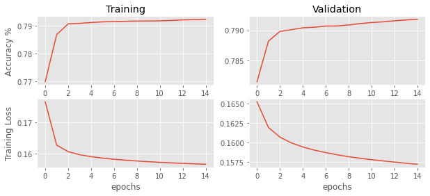

```python
from matplotlib import pyplot as plt

%matplotlib inline

plt.figure(figsize=(10,4))
plt.subplot(2,2,1)
plt.plot(history.history['accuracy'])

plt.ylabel('Accuracy %')
plt.title('Training')
plt.subplot(2,2,2)
plt.plot(history.history['val_accuracy'])
plt.title('Validation')

plt.subplot(2,2,3)
plt.plot(history.history['loss'])
plt.ylabel('Training Loss')
plt.xlabel('epochs')

plt.subplot(2,2,4)
plt.plot(history.history['val_loss'])
plt.xlabel('epochs')
```

#### Q7-Investigate generalization performance by altering the number of layers in the deep branch of the network. Try at least two different number of layers. Use the method of cross validation and evaluation metric that you argued for at the beginning of the lab to select the number of layers that performs superiorly.

```python
# get crossed columns
X_train_crossed = df_train[cross_col_df_names].to_numpy()
X_test_crossed = df_test[cross_col_df_names].to_numpy()

# save categorical features
X_train_cat = df_train[categorical_headers_ints].to_numpy()
X_test_cat = df_test[categorical_headers_ints].to_numpy()

# and save off the numeric features
X_train_num =  df_train[numeric_headers].to_numpy()
X_test_num = df_test[numeric_headers].to_numpy()


# we need to create separate lists for each branch
crossed_outputs = []

# CROSSED DATA INPUT
input_crossed = Input(shape=(X_train_crossed.shape[1],), dtype='int64', name='wide_inputs')
for idx,col in enumerate(cross_col_df_names):

    # track what the maximum integer value will be for this variable
    # which is the same as the number of categories
    N = max(df_train[col].max(),df_test[col].max())+1


    # this line of code does this: input_branch[:,idx]
    x = tf.gather(input_crossed, idx, axis=1)

    # now use an embedding to deal with integers as if they were one hot encoded
    x = Embedding(input_dim=N,
                  output_dim=int(np.sqrt(N)),
                  input_length=1, name=col+'_embed')(x)

    # save these outputs to concatenate later
    crossed_outputs.append(x)
    # now concatenate the outputs and add a fully connected layer
wide_branch = concatenate(crossed_outputs, name='wide_concat')

# reset this input branch
all_deep_branch_outputs = []

# CATEGORICAL DATA INPUT
input_cat = Input(shape=(X_train_cat.shape[1],), dtype='int64', name='categorical_input')
for idx,col in enumerate(categorical_headers_ints):

    # track what the maximum integer value will be for this variable
    # which is the same as the number of categories
    N = max(df_train[col].max(),df_test[col].max())+1

    # this line of code does this: input_branch[:,idx]
    x = tf.gather(input_cat, idx, axis=1)

    # now use an embedding to deal with integers as if they were one hot encoded
    x = Embedding(input_dim=N,
                  output_dim=int(np.sqrt(N)),
                  input_length=1, name=col+'_embed')(x)

    # save these outputs to concatenate later
    all_deep_branch_outputs.append(x)

# NUMERIC DATA INPUT
# create dense input branch for numeric
input_num = Input(shape=(X_train_num.shape[1],), name='numeric')
x_dense = Dense(units=22, activation='relu',name='num_1')(input_num)

all_deep_branch_outputs.append(x_dense)
# merge the deep branches together
deep_branch = concatenate(all_deep_branch_outputs,name='concat_embeds')
deep_branch = Dense(units=75,activation='relu', name='deep1')(deep_branch)
deep_branch = Dense(units=50,activation='relu', name='deep2')(deep_branch)
deep_branch = Dense(units=25,activation='relu', name='deep3')(deep_branch)
deep_branch = Dense(units=10,activation='relu', name='deep4')(deep_branch)

# merge the deep and wide branch
final_branch = concatenate([wide_branch, deep_branch],
                           name='concat_deep_wide')
final_branch = Dense(units=1,activation='sigmoid',
                     name='combined')(final_branch)

model = Model(inputs=[input_crossed,input_cat,input_num],
              outputs=final_branch)
```

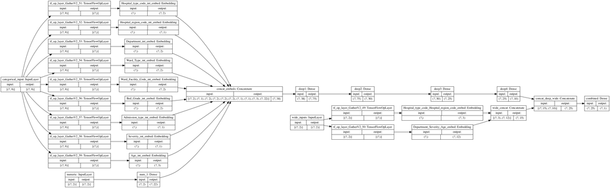

```python
# you will need to install pydot properly on your machine to get this running
plot_model(
    model, to_file='model.png', show_shapes=True, show_layer_names=True,
    rankdir='LR', expand_nested=False, dpi=96
)
# model.summary()
```

```python
%%time

model.compile(optimizer='adagrad',
              loss='mean_squared_error',
              metrics=['accuracy'])

# lets also add the history variable to see how we are doing
# and lets add a validation set to keep track of our progress
history = model.fit([X_train_crossed,X_train_cat,X_train_num],
                    y_train,
                    epochs=15,
                    batch_size=32,
                    verbose=1,
                    validation_data = ([X_test_crossed,X_test_cat,X_test_num],y_test))
```

```
Train on 254660 samples, validate on 63665 samples
CPU times: user 18min 44s, sys: 31min 40s, total: 50min 25s
Wall time: 9min 34s
```

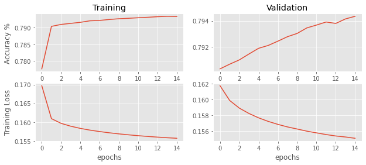

```python
from matplotlib import pyplot as plt

%matplotlib inline

plt.figure(figsize=(10,4))
plt.subplot(2,2,1)
plt.plot(history.history['accuracy'])

plt.ylabel('Accuracy %')
plt.title('Training')
plt.subplot(2,2,2)
plt.plot(history.history['val_accuracy'])
plt.title('Validation')

plt.subplot(2,2,3)
plt.plot(history.history['loss'])
plt.ylabel('Training Loss')
plt.xlabel('epochs')

plt.subplot(2,2,4)
plt.plot(history.history['val_loss'])
plt.xlabel('epochs')
```

```python
yhat = np.round(model.predict([X_test_crossed,X_test_cat,X_test_num]))
print(mt.confusion_matrix(y_test,yhat))
print(mt.classification_report(y_test,yhat))
```

```
[[35765  2110]
 [11122 14668]]
              precision    recall  f1-score   support

           0       0.76      0.94      0.84     37875
           1       0.87      0.57      0.69     25790

    accuracy                           0.79     63665
   macro avg       0.82      0.76      0.77     63665
weighted avg       0.81      0.79      0.78     63665
```

My F1 score was 77% with the 4th layer and it took 9.34 minutes.

```python
# get crossed columns
X_train_crossed = df_train[cross_col_df_names].to_numpy()
X_test_crossed = df_test[cross_col_df_names].to_numpy()

# save categorical features
X_train_cat = df_train[categorical_headers_ints].to_numpy()
X_test_cat = df_test[categorical_headers_ints].to_numpy()

# and save off the numeric features
X_train_num =  df_train[numeric_headers].to_numpy()
X_test_num = df_test[numeric_headers].to_numpy()


# we need to create separate lists for each branch
crossed_outputs = []

# CROSSED DATA INPUT
input_crossed = Input(shape=(X_train_crossed.shape[1],), dtype='int64', name='wide_inputs')
for idx,col in enumerate(cross_col_df_names):

    # track what the maximum integer value will be for this variable
    # which is the same as the number of categories
    N = max(df_train[col].max(),df_test[col].max())+1


    # this line of code does this: input_branch[:,idx]
    x = tf.gather(input_crossed, idx, axis=1)

    # now use an embedding to deal with integers as if they were one hot encoded
    x = Embedding(input_dim=N,
                  output_dim=int(np.sqrt(N)),
                  input_length=1, name=col+'_embed')(x)

    # save these outputs to concatenate later
    crossed_outputs.append(x)
    # now concatenate the outputs and add a fully connected layer
wide_branch = concatenate(crossed_outputs, name='wide_concat')

# reset this input branch
all_deep_branch_outputs = []

# CATEGORICAL DATA INPUT
input_cat = Input(shape=(X_train_cat.shape[1],), dtype='int64', name='categorical_input')
for idx,col in enumerate(categorical_headers_ints):

    # track what the maximum integer value will be for this variable
    # which is the same as the number of categories
    N = max(df_train[col].max(),df_test[col].max())+1

    # this line of code does this: input_branch[:,idx]
    x = tf.gather(input_cat, idx, axis=1)

    # now use an embedding to deal with integers as if they were one hot encoded
    x = Embedding(input_dim=N,
                  output_dim=int(np.sqrt(N)),
                  input_length=1, name=col+'_embed')(x)

    # save these outputs to concatenate later
    all_deep_branch_outputs.append(x)

# NUMERIC DATA INPUT
# create dense input branch for numeric
input_num = Input(shape=(X_train_num.shape[1],), name='numeric')
x_dense = Dense(units=22, activation='relu',name='num_1')(input_num)

all_deep_branch_outputs.append(x_dense)
# merge the deep branches together
deep_branch = concatenate(all_deep_branch_outputs,name='concat_embeds')
deep_branch = Dense(units=50,activation='relu', name='deep1')(deep_branch)
deep_branch = Dense(units=25,activation='relu', name='deep2')(deep_branch)

# merge the deep and wide branch
final_branch = concatenate([wide_branch, deep_branch],
                           name='concat_deep_wide')
final_branch = Dense(units=1,activation='sigmoid',
                     name='combined')(final_branch)

model = Model(inputs=[input_crossed,input_cat,input_num],
              outputs=final_branch)
```

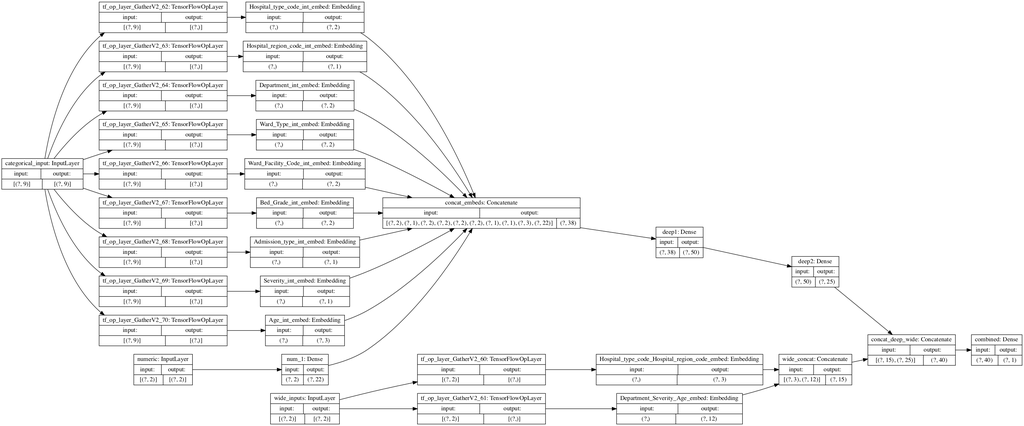

```python
# you will need to install pydot properly on your machine to get this running
plot_model(
    model, to_file='model.png', show_shapes=True, show_layer_names=True,
    rankdir='LR', expand_nested=False, dpi=96
)
# model.summary()
```

```python
%%time

model.compile(optimizer='adagrad',
              loss='mean_squared_error',
              metrics=['accuracy'])

# lets also add the history variable to see how we are doing
# and lets add a validation set to keep track of our progress
history = model.fit([X_train_crossed,X_train_cat,X_train_num],
                    y_train,
                    epochs=15,
                    batch_size=32,
                    verbose=1,
                    validation_data = ([X_test_crossed,X_test_cat,X_test_num],y_test))
```

```
Train on 254660 samples, validate on 63665 samples
CPU times: user 11min 29s, sys: 1min 20s, total: 12min 50s
Wall time: 5min 20s
```

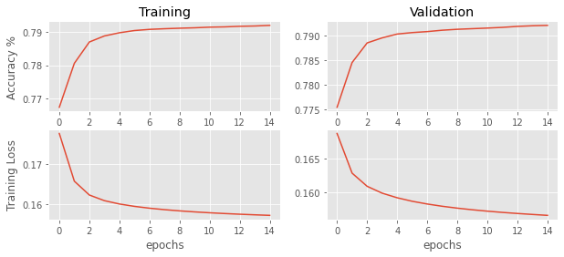

```python
from matplotlib import pyplot as plt

%matplotlib inline

plt.figure(figsize=(10,4))
plt.subplot(2,2,1)
plt.plot(history.history['accuracy'])

plt.ylabel('Accuracy %')
plt.title('Training')
plt.subplot(2,2,2)
plt.plot(history.history['val_accuracy'])
plt.title('Validation')

plt.subplot(2,2,3)
plt.plot(history.history['loss'])
plt.ylabel('Training Loss')
plt.xlabel('epochs')

plt.subplot(2,2,4)
plt.plot(history.history['val_loss'])
plt.xlabel('epochs')
```

```python
yhat = np.round(model.predict([X_test_crossed,X_test_cat,X_test_num]))
print(mt.confusion_matrix(y_test,yhat))
print(mt.classification_report(y_test,yhat))
```

[output not shown]

```python
print('RF test roc-auc: {}'.format(roc_auc_score(y_test,yhat)))
```

[output not shown]

#### Q8-Compare the performance of your best wide and deep network to a standard multi-layer perceptron (MLP).

```python
#Example adapted from https://github.com/rasbt/python-machine-learning-book/blob/master/code/ch12/ch12.ipynb
#Original Author: Sebastian Raschka

import numpy as np
from scipy.special import expit
import sys
import pandas as pd

# start with a simple base classifier, which can't be fit or predicted
# it only has internal classes to be used by classes that will subclass it
# Start with the following functions:
#    init
#    encode_labels
#    initialize weights
#    sigmoid
#    add bias (vector of ones)
#    objective function (cost and regularizer)
class TwoLayerPerceptronBase(object):
    def __init__(self, n_hidden=30,
                 C=0.0, epochs=500, eta=0.001, random_state=None):
        np.random.seed(random_state)
        self.n_hidden = n_hidden
        self.l2_C = C
        self.epochs = epochs
        self.eta = eta

    @staticmethod
    def _encode_labels(y):
        """Encode labels into one-hot representation"""
        onehot = pd.get_dummies(y).values.T

        return onehot
    def _initialize_weights(self):
        """Initialize weights with small random numbers."""
        W1_num_elems = (self.n_features_ + 1)*self.n_hidden
        W1 = np.random.uniform(-1.0, 1.0, size=W1_num_elems)
        W1 = W1.reshape(self.n_hidden, self.n_features_ + 1) # reshape to be W

        W2_num_elems = (self.n_hidden + 1)*self.n_output_
        W2 = np.random.uniform(-1.0, 1.0, size=W2_num_elems)
        W2 = W2.reshape(self.n_output_, self.n_hidden + 1)
        return W1, W2

    @staticmethod
    def _sigmoid(z):
        """Use scipy.special.expit to avoid overflow"""
        # 1.0 / (1.0 + np.exp(-z))
        return expit(z)

    @staticmethod
    def _add_bias_unit(X, how='column'):
        """Add bias unit (column or row of 1s) to array at index 0"""
        if how == 'column':
            ones = np.ones((X.shape[0], 1))
            X_new = np.hstack((ones, X))
        elif how == 'row':
            ones = np.ones((1, X.shape[1]))
            X_new = np.vstack((ones, X))
        return X_new
    @staticmethod
    def _L2_reg(lambda_, W1, W2):
        """Compute L2-regularization cost"""
        # only compute for non-bias terms
        return (lambda_) * np.sqrt(np.mean(W1[:, 1:] ** 2) + np.mean(W2[:, 1:] ** 2))

    def _cost(self,A3,Y_enc,W1,W2):
        '''Get the objective function value'''
        cost = np.mean((Y_enc-A3)**2)
        L2_term = self._L2_reg(self.l2_C, W1, W2)
        return cost + L2_term
```

```python
# now let's add in the following functions:
#    feedforward
#    fit and predict
class TwoLayerPerceptron(TwoLayerPerceptronBase):
    def _feedforward(self, X, W1, W2):
        """Compute feedforward step
        -----------
        X : Input layer with original features.
        W1: Weight matrix for input layer -> hidden layer.
        W2: Weight matrix for hidden layer -> output layer.
        ----------
        a1-a3 : activations into layer (or output layer)
        z1-z2 : layer inputs

        """
        A1 = self._add_bias_unit(X.T, how='row')
        Z1 = W1 @ A1
        A2 = self._sigmoid(Z1)
        A2 = self._add_bias_unit(A2, how='row')
        Z2 = W2 @ A2
        A3 = self._sigmoid(Z2)
        return A1, Z1, A2, Z2, A3

    def _get_gradient(self, A1, A2, A3, Z1, Z2, Y_enc, W1, W2):
        """ Compute gradient step using backpropagation.
        """
        # need to vectorize this computation!
        # See additional code and derivation below!

    def predict(self, X):
        """Predict class labels"""
        _, _, _, _, A3 = self._feedforward(X, self.W1, self.W2)
        y_pred = np.argmax(A3, axis=0)
        return y_pred
    def fit(self, X, y, print_progress=False):
        """ Learn weights from training data."""

        X_data, y_data = X.copy(), y.copy()
        Y_enc = self._encode_labels(y)

        # init weights and setup matrices
        self.n_features_ = X_data.shape[1]
        self.n_output_ = Y_enc.shape[0]
        self.W1, self.W2 = self._initialize_weights()

        self.cost_ = []
        for i in range(self.epochs):

            if print_progress>0 and (i+1)%print_progress==0:
                sys.stderr.write('\rEpoch: %d/%d' % (i+1, self.epochs))
                sys.stderr.flush()

            # feedforward all instances
            A1, Z1, A2, Z2, A3 = self._feedforward(X_data,self.W1,self.W2)

            cost = self._cost(A3,Y_enc,self.W1,self.W2)
            self.cost_.append(cost)

            # compute gradient via backpropagation
            grad1, grad2 = self._get_gradient(A1=A1, A2=A2, A3=A3, Z1=Z1, Z2=Z2, Y_enc=Y_enc,
                                              W1=self.W1, W2=self.W2)

            self.W1 -= self.eta * grad1
            self.W2 -= self.eta * grad2


        return self
```

```python
params = dict(n_hidden=50,
              C=0.1, # tradeoff L2 regularizer
              epochs=400, # iterations
              eta=0.001,  # learning rate
              random_state=1)
```

```python
class TwoLayerPerceptronVectorized(TwoLayerPerceptron):
    # just need a different gradient calculation
    def _get_gradient(self, A1, A2, A3, Z1, Z2, Y_enc, W1, W2):
        """ Compute gradient step using backpropagation.
        """
        # vectorized backpropagation
        V2 = -2*(Y_enc-A3)*A3*(1-A3)
        V1 = A2*(1-A2)*(W2.T @ V2)

        grad2 = V2 @ A2.T
        grad1 = V1[1:,:] @ A1.T


        # regularize weights that are not bias terms
        grad1[:, 1:] += W1[:, 1:] * self.l2_C
        grad2[:, 1:] += W2[:, 1:] * self.l2_C

        return grad1, grad2
```

```python
%%time
nn = TwoLayerPerceptronVectorized(**params)

nn.fit(X_train, y_train, print_progress=50)
yhat = nn.predict(X_test)
print('Accuracy:',accuracy_score(y_test,yhat))
```

```
Epoch: 400/400
```

```
Accuracy: 0.594910861540878
CPU times: user 7min 25s, sys: 56.4 s, total: 8min 21s
Wall time: 1min 4s
```

```python
print('RF test roc-auc: {}'.format(roc_auc_score(y_test,yhat)))
```

```
RF test roc-auc: 0.5
```

I got 59% accuracy and Standard multi layer perceptron doesn't work well here because in the Tensor flow, we are using different optimizers and more number of neurons for Tensor flow claculations.

#### Alternatively, you can compare to a network without the wide branch (i.e., just the deep network). For classification tasks, compare using the receiver operating characteristic and area under the curve. For regression tasks, use Bland-Altman plots and residual variance calculations. Use proper statistical methods to compare the performance of different models.

```python
# get crossed columns
#X_train_crossed = df_train[cross_col_df_names].to_numpy()
#X_test_crossed = df_test[cross_col_df_names].to_numpy()

# save categorical features
X_train_cat = df_train[categorical_headers_ints].to_numpy()
X_test_cat = df_test[categorical_headers_ints].to_numpy()

# and save off the numeric features
X_train_num =  df_train[numeric_headers].to_numpy()
X_test_num = df_test[numeric_headers].to_numpy()


# we need to create separate lists for each branch
#crossed_outputs = []

# # CROSSED DATA INPUT
# input_crossed = Input(shape=(X_train_crossed.shape[1],), dtype='int64', name='wide_inputs')
# for idx,col in enumerate(cross_col_df_names):

#     # track what the maximum integer value will be for this variable
#     # which is the same as the number of categories
#     N = max(df_train[col].max(),df_test[col].max())+1


#     # this line of code does this: input_branch[:,idx]
#     x = tf.gather(input_crossed, idx, axis=1)

#     # now use an embedding to deal with integers as if they were one hot encoded
#     x = Embedding(input_dim=N,
#                   output_dim=int(np.sqrt(N)),
#                   input_length=1, name=col+'_embed')(x)

    # save these outputs to concatenate later
    #crossed_outputs.append(x)
    # now concatenate the outputs and add a fully connected layer
#wide_branch = concatenate(crossed_outputs, name='wide_concat')

# reset this input branch
all_deep_branch_outputs = []

# CATEGORICAL DATA INPUT
input_cat = Input(shape=(X_train_cat.shape[1],), dtype='int64', name='categorical_input')
for idx,col in enumerate(categorical_headers_ints):

    # track what the maximum integer value will be for this variable
    # which is the same as the number of categories
    N = max(df_train[col].max(),df_test[col].max())+1

    # this line of code does this: input_branch[:,idx]
    x = tf.gather(input_cat, idx, axis=1)

    # now use an embedding to deal with integers as if they were one hot encoded
    x = Embedding(input_dim=N,
                  output_dim=int(np.sqrt(N)),
                  input_length=1, name=col+'_embed')(x)

    # save these outputs to concatenate later
    all_deep_branch_outputs.append(x)

# NUMERIC DATA INPUT
# create dense input branch for numeric
input_num = Input(shape=(X_train_num.shape[1],), name='numeric')
x_dense = Dense(units=22, activation='relu',name='num_1')(input_num)

all_deep_branch_outputs.append(x_dense)
# merge the deep branches together
deep_branch = concatenate(all_deep_branch_outputs,name='concat_embeds')
deep_branch = Dense(units=50,activation='relu', name='deep1')(deep_branch)
deep_branch = Dense(units=25,activation='relu', name='deep2')(deep_branch)

# merge the deep and wide branch
#final_branch = concatenate([wide_branch, deep_branch],
                          #name='concat_deep_wide')
final_branch = deep_branch
final_branch = Dense(units=1,activation='sigmoid',
                     name='combined')(final_branch)

model = Model(inputs=[input_cat,input_num],
              outputs=final_branch)
```

```python
%%time

model.compile(optimizer='adagrad',
              loss='mean_squared_error',
              metrics=['accuracy'])

# lets also add the history variable to see how we are doing
# and lets add a validation set to keep track of our progress
history = model.fit([X_train_cat,X_train_num],
                    y_train,
                    epochs=15,
                    batch_size=32,
                    verbose=1,
                    validation_data = ([X_test_cat,X_test_num],y_test))
```

```
Train on 254660 samples, validate on 63665 samples
CPU times: user 9min 52s, sys: 1min 9s, total: 11min 1s
Wall time: 4min 41s
```

```python
yhat = np.round(model.predict([X_test_cat,X_test_num]))
print(mt.confusion_matrix(y_test,yhat))
print(mt.classification_report(y_test,yhat))
```

```
[[35665  2210]
 [11146 14644]]
              precision    recall  f1-score   support

           0       0.76      0.94      0.84     37875
           1       0.87      0.57      0.69     25790

    accuracy                           0.79     63665
   macro avg       0.82      0.75      0.76     63665
weighted avg       0.81      0.79      0.78     63665
```

```python
print('RF test roc-auc: {}'.format(roc_auc_score(y_test,yhat)))
```

```
RF test roc-auc: 0.7547335741716863
```

ROC -

1. 90-100 : excellent
2. 80-90 : good
3. 70-80 : fair
4. 60-70 : poor
5. 50-60 : fail

Multi layer perceptron ROC was 50% and failed model, we cannot use MLP for this dataset.

#### Exceptional Work

```python
embeddings = model.get_layer(col+'_embed').get_weights()[0]
embeddings.shape
```

```
(10, 3)
```

```python
embeddings_df = pd.DataFrame(embeddings)
embeddings_df
```

|  | 0 | 1 | 2 |
| --- | --- | --- | --- |
| 0 | 0.115761 | 0.044041 | -0.056626 |
| 1 | 0.115953 | 0.069356 | -0.118219 |
| 2 | 0.041590 | 0.056569 | 0.005963 |
| 3 | -0.041438 | 0.031629 | -0.011159 |
| 4 | 0.021959 | 0.082109 | 0.006860 |
| 5 | 0.047250 | 0.095753 | -0.078008 |
| 6 | 0.076351 | 0.099702 | -0.025315 |
| 7 | -0.021495 | 0.018948 | -0.001971 |
| 8 | -0.078119 | -0.079103 | 0.058390 |
| 9 | -0.015528 | -0.048837 | 0.037433 |

```python
from sklearn.manifold import TSNE
tsne = TSNE(n_components=2,verbose=1,perplexity=40,random_state=0)
tsne_results = tsne.fit_transform(embeddings_df)
```

```
[t-SNE] Computing 9 nearest neighbors...
[t-SNE] Indexed 10 samples in 0.000s...
[t-SNE] Computed neighbors for 10 samples in 0.002s...
[t-SNE] Computed conditional probabilities for sample 10 / 10
[t-SNE] Mean sigma: 1125899906842624.000000
[t-SNE] KL divergence after 250 iterations with early exaggeration: 45.072975
[t-SNE] KL divergence after 1000 iterations: 0.250687
```

```python
tsne_results
```

```
array([[ 32.42095  ,   8.11523  ],
       [  0.6489552,  71.7071   ],
       [ 71.019684 ,   9.971006 ],
       [  3.7859814,  33.185135 ],
       [-42.6665   ,  -9.22207  ],
       [ -3.6216893, -43.526516 ],
       [ -3.6324017,  -4.1717076],
       [-36.5844   ,  35.804413 ],
       [ 44.39138  ,  50.615383 ],
       [ 40.23581  , -31.591665 ]], dtype=float32)
```

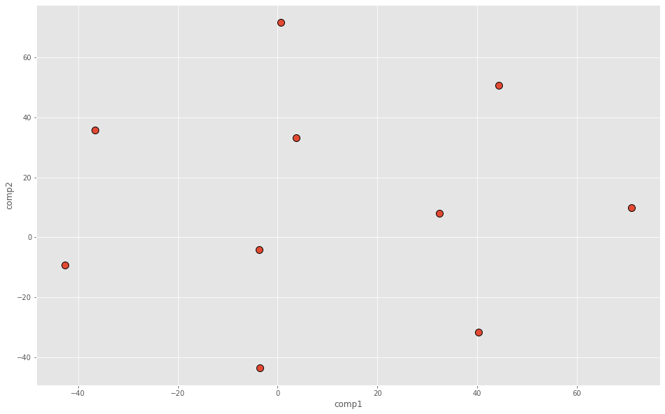

```python
tsne_df = pd.DataFrame()
tsne_df=tsne_df.rename({0:'Hospital_type_code', 1:'Hospital_region_code',
       2:'Extra_Rooms', 3:'Department', 4:'Ward_Type',
       5:'Ward_Facility_Code', 6:'Bed_Grade', 7:'Admission_type',
       8:'Severity', 9:'Visitors'})
tsne_df['comp1'] = tsne_results[:,0]
tsne_df['comp2'] = tsne_results[:,1]
plt.figure(figsize=(16,10))
sns.scatterplot(
        x='comp1',
        y='comp2',
        s=100,
        cmap='Spectral',
        edgecolor='black',
        linewidth = 1,
        data=tsne_df,
        alpha=1
 )
```